# 1.Data_cleaning

## Jorge Bueno Perez - 419034

## Prediction of the average price of the Spanish rail tickets data

```python
import numpy as np
import pandas as pd
import os

os.environ["KERAS_BACKEND"] = "plaidml.keras.backend" # most important part

import keras
import keras.applications as kapp
from keras.datasets import cifar10
```

```
Using plaidml.keras.backend backend.
```

```python
renfe= pd.read_csv("~/Desktop/Projects/DL/Regression/Before_modeling/Datasets/Original/thegurus-opendata-renfe-trips.csv")
```

### The data initially contains `14 columns`

```python
renfe.head() # 14 columns
```

|  | id | company | origin | destination | departure | arrival | duration | vehicle_type | vehicle_class | price | fare | seats | meta | insert_date |
| --- | --- | --- | --- | --- | --- | --- | --- | --- | --- | --- | --- | --- | --- | --- |
| 0 | 1 | renfe | MADRID | BARCELONA | 2019-04-18 05:50:00 | 2019-04-18 08:55:00 | 3.08 | AVE | Preferente | 68.95 | Promo | NaN | {} | 2019-04-11 21:49:46 |
| 1 | 2 | renfe | MADRID | BARCELONA | 2019-04-18 13:25:00 | 2019-04-18 16:24:00 | 2.98 | AVE-TGV | Turista | 107.70 | Flexible | NaN | {} | 2019-04-11 21:49:46 |
| 2 | 3 | renfe | MADRID | BARCELONA | 2019-04-18 06:30:00 | 2019-04-18 09:20:00 | 2.83 | AVE | Turista | 75.40 | Promo | NaN | {} | 2019-04-11 21:49:46 |
| 3 | 4 | renfe | MADRID | BARCELONA | 2019-04-18 15:30:00 | 2019-04-18 18:40:00 | 3.17 | AVE | Preferente | NaN | Promo | NaN | {} | 2019-04-11 21:49:46 |
| 4 | 5 | renfe | MADRID | BARCELONA | 2019-04-18 07:00:00 | 2019-04-18 09:30:00 | 2.50 | AVE | Turista Plus | 106.75 | Promo | NaN | {} | 2019-04-11 21:49:46 |

# 1) `Filter the columns`:

### After that `eight columns` are going to be selected

```python
renfe = renfe.filter(["origin", "destination", "departure", "duration",
             "vehicle_type","vehicle_class", "price", "fare"])
```

### At this point the data contains `38,753,060 rows` and `8 columns`

```python
renfe.shape[0]
```

```
38753060
```

```python
renfe.shape[1]
```

```
8
```

# 2) `Removing NaN and zero valus`:

### All the rows with a `zero` or `NaN` values are going to be removed

```python
renfe.isnull().sum()
```

```
origin                 0
destination            0
departure              0
duration               0
vehicle_type           0
vehicle_class    8034239
price            9159949
fare             8034239
dtype: int64
```

```python
renfe.dropna(inplace=True)
```

```python
len(renfe[(renfe['price'] == 0)])
```

```
102
```

```python
renfe = renfe[(renfe['price'] != 0)]
```

# 3) `Grouping by the same kind of travel, price as average`:

### As it was seen before the data contains `38,753,060 rows`. There are so many because the data was daily scrapped from the Spanish railway website. This means, that the `same kind of travels were scrapped several times`

### For the purpose of this project, which is to `predict the average price`, firstly we should group the same kind of travels, this means same `origin`, `destination`, `departure`, `duration`, `vehicle_type`, `vehicle_class` and `fare`, then returning the averaga `price` in the column with the same name

```python
renfe = renfe.groupby(['origin', 'destination', 'departure', 'duration', 'vehicle_type', 'vehicle_class', 'fare'], as_index=False)['price'].mean()
```

# 4) `Removing outliers`:

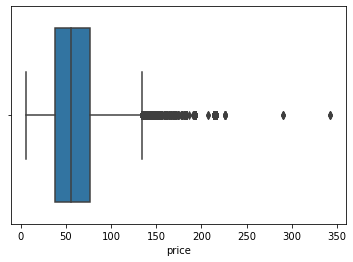

```python
import seaborn as sns
sns.boxplot(x= renfe['price'])
```

### As per the `box plot`graph, it seems there are some `outliers`, however we should check this deeper

```python
sum(renfe.price > 250) / len(renfe) * 100
```

```
0.002367256113438913
```

### It appears that only `0.0023%` of the data is `greater than the price equal to 250 EUR`, hence we will delete the rows with values in which the price is greater than 250 EUR

```python
sum(renfe.price > 250)
```

```
6
```

```python
renfe = renfe[renfe.price < 250]
```

### Only `6 values` were deleated

# 5) `Spliting departure column`:

### The column `departure` shows the departure time of the train

### This `datetime`is going to be splitted in the following ones:

- `week_day`: It shows the day of the week, from `Monday= 0`, to `Sunday= 6`
- `month`: It shows the number of the month, from `January= 1`, to `December= 12`
- `year`: It shows the `year`
- `time`: In `hours` and `minutes`

```python
renfe['departure'] = pd.to_datetime(renfe['departure']).dt.strftime('%Y-%m-%d %H:%M')
renfe['week_day'] = pd.to_datetime(renfe['departure']).dt.dayofweek # Monday=0, Sunday=6
renfe['month'] = pd.to_datetime(renfe['departure']).dt.strftime('%m')
renfe['year'] = pd.to_datetime(renfe['departure']).dt.strftime('%Y')
renfe['time'] = pd.to_datetime(renfe['departure']).dt.strftime('%H:%M')
```

### After the `splitting`of the column `departure`, the same will be removed from the dataset

```python
del renfe['departure']
```

```python
#renfe.to_csv("~/Desktop/Projects/DL/Regression/Before_modeling/Datasets/renfe.csv", index=False)
```